Alicia Fazzone - CS 544 Term Project

## Suicides Rates Overview 1995 to 2014

The following report is from the suicides rates overview dataset on Kaggle. https://www.kaggle.com/russellyates88/suicide-rates-overview-1985-to-2016 . I did some data pre-processing on the dataset removing years and countries that did not have sufficient data, and arrived at a 20 year span from 1995 - 2014 for 70 countries. The attributes in the dataset are broken down granularly by age country, age group, sex, then shows number of suicides and number of suicides per 100k for each of those groupings. The following barchart shows the aggregate total number of suicides per year.

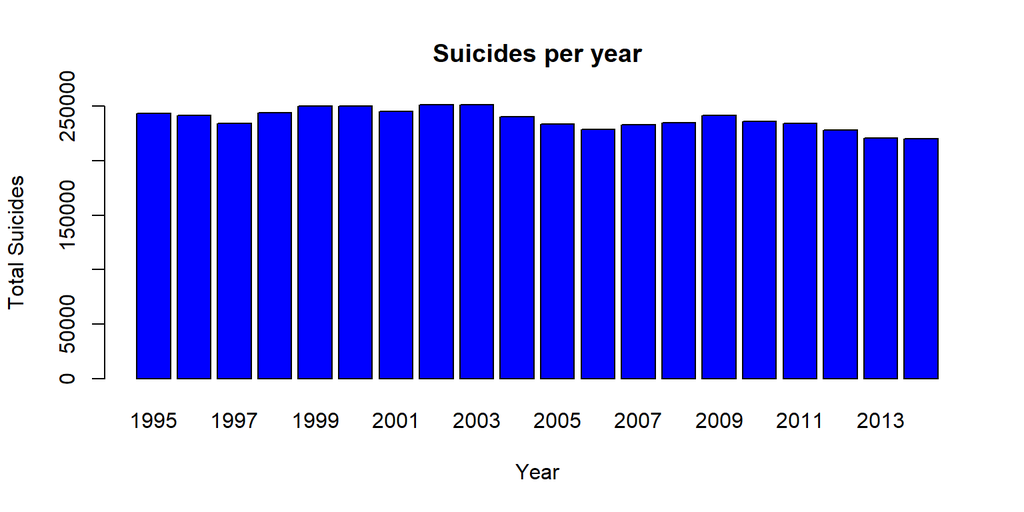

```r
library(plotly)

library(dplyr)
library(tidyverse)
library(ggplot2)

df <-read.csv(file = 'C:/Users/HP/Documents/544/CS544_Project_Fazzone/data.csv')

tib <- as_tibble(df)

year_total <- tib %>% group_by(year) %>% summarise(sum(suicides_no))


years <- pull(year_total, year)
per_year <- pull(year_total, c(2))

barplot(per_year, main = "Suicides per year",xlab = "Year",
        ylab = "Total Suicides", names = years, col = "blue")
```

## Age Distribution

The following is the cumulative total number of suicides for age groupings across all countries

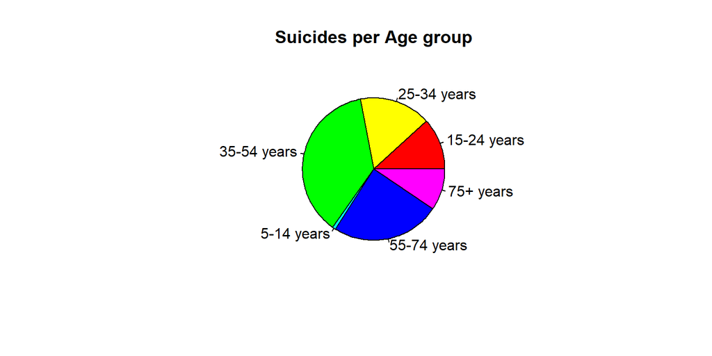

```
## # A tibble: 6 x 2
##   age         `sum(suicides_no)`
##   <chr>                    <int>
## 1 15-24 years             561939
## 2 25-34 years             771728
## 3 35-54 years            1772947
## 4 5-14 years               36511
## 5 55-74 years            1170287
## 6 75+ years               450986
```

## Summary of Suicides per 100k population by age group

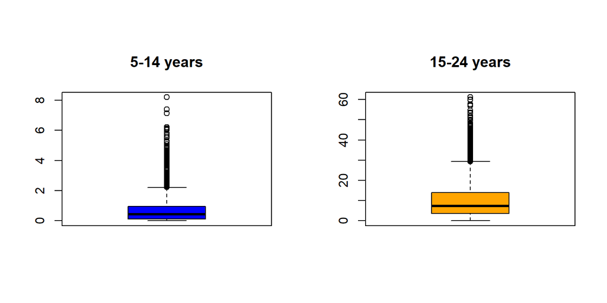

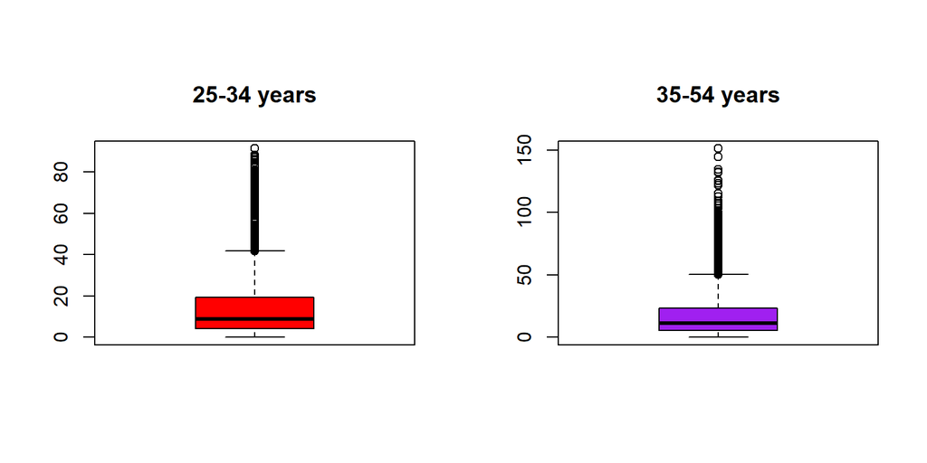

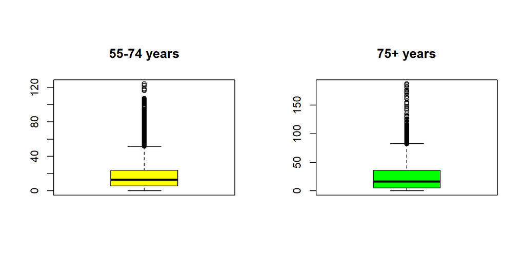

## The following Mosaic Plot shows the aggregate age groups by sex across all countries

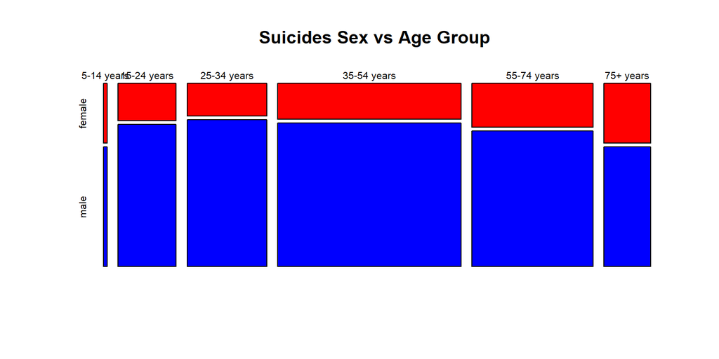

```
##        5-14 years 15-24 years 25-34 years 35-54 years 55-74 years 75+ years
## female      12185      117691      140576      355875      287550    150323
## male        24326      444248      631152     1417072      882737    300663
```

## Distribution of suicides per 100K population is right skewed

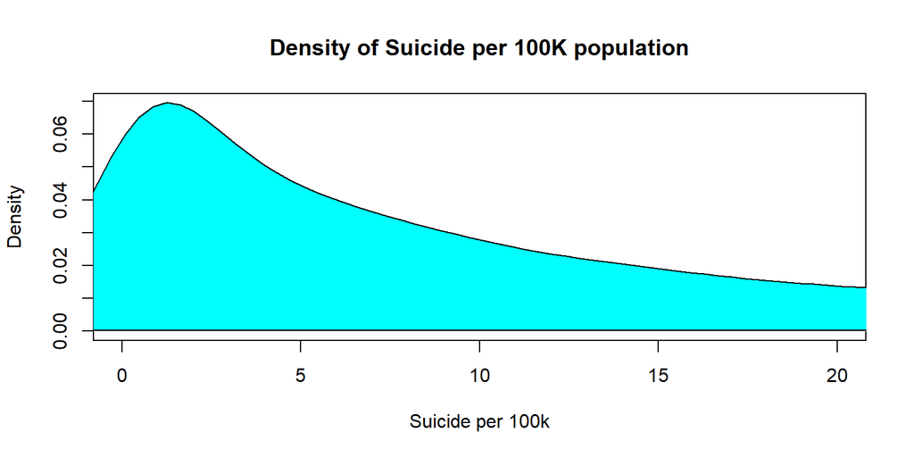

## Selected Different Size samples to test the Central Limit Theorm

Since every yearly entry for every country contained the age group under 15 years old for both male and female, there were a lot of zeros in this data since that age groups was 1/6 of the total values.

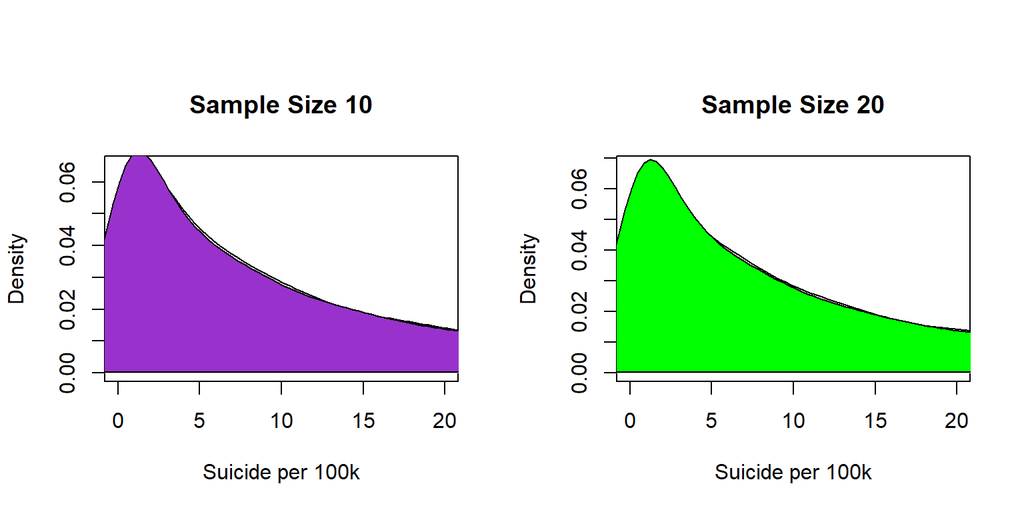

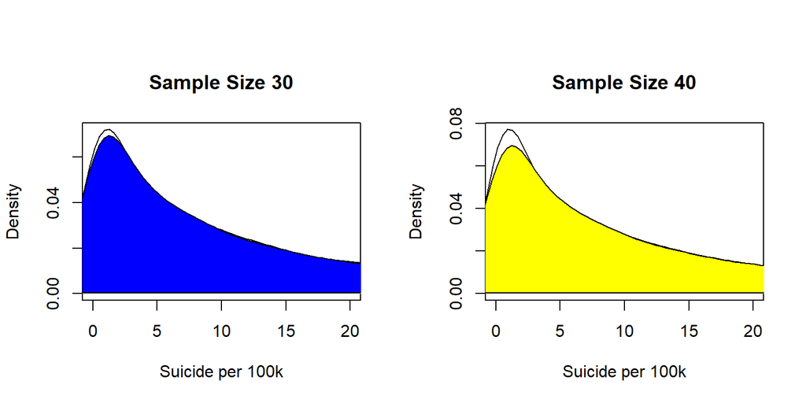

```
## # A tibble: 6 x 2
##   age         `sum(suicides_no)`
##   <chr>                    <int>
## 1 15-24 years              15948
## 2 25-34 years              17631
## 3 35-54 years              37119
## 4 5-14 years                1418
## 5 55-74 years              37139
## 6 75+ years                20656
```

```
## # A tibble: 6 x 2
##   age         `sum(suicides_no)`
##   <chr>                    <int>
## 1 15-24 years              56295
## 2 25-34 years             100318
## 3 35-54 years             237753
## 4 5-14 years                2463
## 5 55-74 years             113200
## 6 75+ years                24888
```

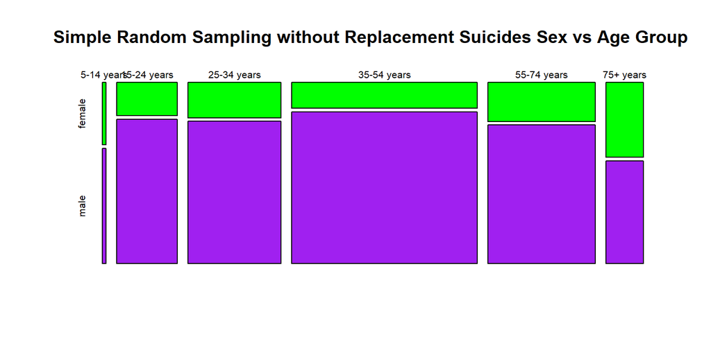

## Systematic Sampling

```
## # A tibble: 6 x 2
##   age         `sum(suicides_no)`
##   <chr>                    <int>
## 1 15-24 years              23315
## 2 25-34 years              12698
## 3 35-54 years              72800
## 4 5-14 years                 409
## 5 55-74 years               9527
## 6 75+ years                35162
```

```
## # A tibble: 6 x 2
##   age         `sum(suicides_no)`
##   <chr>                    <int>
## 1 15-24 years              95042
## 2 25-34 years              39555
## 3 35-54 years             220524
## 4 5-14 years                   1
## 5 55-74 years              97869
## 6 75+ years                67853
```

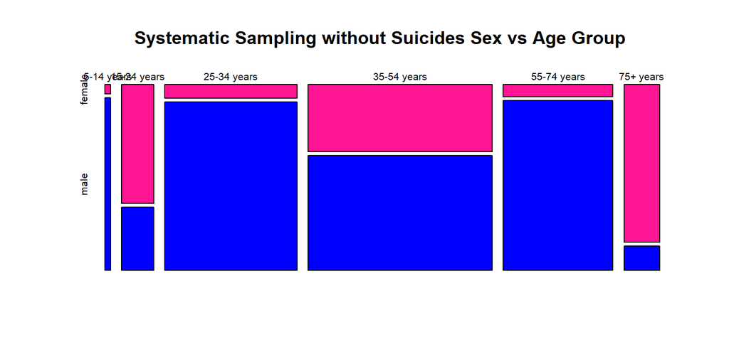

## The following shows the mean suicide number per 100k per country

[figure not shown]